# Highways and Air Pollution

Author

Jason Roettger

## Introduction

All people, from all walks of life, need clean air to survive. As such, I seek to identify how the presence of highways in a county impacts the air quality in that county. The data I use for this analysis is drawn from reputable public and private sources. I draw air quality data, as measured by an air quality index (AQI), from the United States Environmental Protection Agency (EPA). Highway data was drawn from the Federal Reserve Bank of Philadelphia Research Department, which compiled the data from the US Census Bureau. County-level data regarding various measures used as controls or for calculating controls (population, the proportion of people living in urban areas, median age, median family income, median years of schooling for individuals aged 25 and up, and land area) were pulled from the 1950 decennial US Census through the IPUMS NHGIS website. My analysis relies on the use of the 1947 US Interstate Highway Plan as an instrument for modern highway presence because of concerns regarding confounding factors. I find that increasing the length of highway present in a county increases the typical and most extreme amounts of air pollution in that county, but the effect appears to be relatively small. However, the magnitude of the estimated effect only applies to counties in which the 1947 US Interstate Highway Plan influenced the amount of modern highways in the county. Although the results of my research cannot be generalized to the US as a whole, it has still revealed a valuable relationship between highway length and air quality. We now know that expanding our highway system will have negative air quality consequences locally, which government officials can take into consideration when planning new highway expansions. The rest of this paper is organized as follows: a review of the sparse relevant literature already existing on the topic; an explanation of my data sources, cleaning, and usefulness; an explanation of my empirical strategy, including an evaluation of my assumptions; my results; and my conclusion.

## Data

```r
library("modelsummary")
library("ggplot2")
library("sf")
library("dplyr")
library("fixest")
library("kableExtra")
library("tidyr")

#Air pollution data
data <- read.csv("C:/Users/Jason/OneDrive/Documents/School Fall 2024/ECON 708/Project/annual_aqi_by_county_2024.csv")

#Population data
data2 <- read.csv("C:/Users/Jason/OneDrive/Documents/School Fall 2024/ECON 708/Project/nhgis0001_ds83_1950_county.csv")

#Other control Data
data3 <- read.csv("C:/Users/Jason/OneDrive/Documents/School Fall 2024/ECON 708/Project/nhgis0001_ds84_1950_county.csv")

#Highway data
data4 <- readRDS("C:/Users/Jason/OneDrive/Documents/School Fall 2024/ECON 708/Project/MAPS/step_01_fips_02.rds")

#Creates a state lookup based on fips
fips_lookup <- data.frame(
  STATEFP = c("01", "02", "04", "05", "06", "08", "09", "10", "11", "12", "13", "15", "16", "17", "18", "19", "20", "21", "22", "23", "24", "25", "26", "27", "28", "29", "30", "31", "32", "33", "34", "35", "36", "37", "38", "39", "40", "41", "42", "44", "45", "46", "47", "48", "49", "50", "51", "53", "54", "55", "56"),
  state = c("Alabama", "Alaska", "Arizona", "Arkansas", "California", "Colorado", "Connecticut", "Delaware", "District of Columbia", "Florida", "Georgia", "Hawaii", "Idaho", "Illinois", "Indiana", "Iowa", "Kansas", "Kentucky", "Louisiana", "Maine", "Maryland", "Massachusetts", "Michigan", "Minnesota", "Mississippi", "Missouri", "Montana", "Nebraska", "Nevada", "New Hampshire", "New Jersey", "New Mexico", "New York", "North Carolina", "North Dakota", "Ohio", "Oklahoma", "Oregon", "Pennsylvania", "Rhode Island", "South Carolina", "South Dakota", "Tennessee", "Texas", "Utah", "Vermont", "Virginia", "Washington", "West Virginia", "Wisconsin", "Wyoming")
)

#Adds state names to highway data
data4 <- data4 %>%
  left_join(fips_lookup, by = "STATEFP")

#Rename state and county variables to be consistent for joining
data <- data %>% rename(state = State, county = County)
data2 <- data2 %>% rename(state = STATE, county = COUNTY)
data3 <- data3 %>% rename(state = STATE, county = COUNTY)
data4 <- data4 %>% rename(county = NAME)

#Joins the datasets
joined_data <- data %>%
  left_join(data2, by = c("state", "county")) %>%
  left_join(data3, by = c("state", "county")) %>%
  left_join(data4, by = c("state", "county"))

#removes NA values
joined_data <- na.omit(joined_data)

#renames columns and removes extra columns
fin_data <- joined_data %>%
  rename(
    state = state,
    county = county,
    aqi_maximum = Max.AQI,
    aqi_90th_percentile = X90th.Percentile.AQI,
    aqi_median = Median.AQI,
    population = B1N001,
    proportion_urban = B20001,
    median_age = B21001,
    median_family_income = B22001,
    median_school_years = B24001,
    area_acres = B3I001,
    planned_hw_meters = old_hw_length_in_m,
    actual_hw_meters = new_hw_length_in_m
  ) %>%
  select(state, county, aqi_maximum, aqi_90th_percentile, aqi_median, population, proportion_urban, median_age, median_family_income, median_school_years, area_acres, planned_hw_meters, actual_hw_meters)

#Removes blank cells
fin_data <- fin_data %>% filter_all(all_vars(. != ""))

#Converts text to value
urban_map <- data.frame(
  proportion_urban = c("0% to 9.9%", "10% to 19.9%", "20% to 29.9%", "30% to 39.9%", "40% to 49.9%", "50% to 59.9%", "60% to 69.9%", "70% to 79.9%", "80% to 89.9%", "90% to 99.9%"),
  proportion_urban_decimal = c(0.05, 0.15, 0.25, 0.35, 0.45, 0.55, 0.65, 0.75, 0.85, 0.95)
)
fin_data <- fin_data %>%
  left_join(urban_map, by = "proportion_urban")

#Converts text to value
age_map <- data.frame(
  median_age = c("14 to 17 years", "18 to 21 years", "22 to 25 years", "26 to 29 years", "30 to 33 years", "34 to 37 years", "38 to 41 years"),
  median_age_value = c(15.5, 19.5, 23.5, 27.5, 31.5, 35.5, 39.5)
)
fin_data <- fin_data %>%
  left_join(age_map, by = "median_age")

#Converts text to value
income_map <- data.frame(
  median_family_income = c("$500 to $999", "$1,000 to $1,499", "$1,500 to $1,999", "$2,000 to $2,499", "$2,500 to $2,999", "$3,000 to $3,499", "$3,500 to $3,999", "$4,000 to $4,999"),
  median_family_income_value = c(750, 1250, 1750, 2250, 2750, 3250, 3750, 4500)
)
fin_data <- fin_data %>%
  left_join(income_map, by = "median_family_income")

#Removes values that cannot be used
#fin_data <- fin_data %>%
  #filter(median_school_years != "4.9 years or less")

#Converts text to value
years_map <- data.frame(
  median_school_years = c("4.9 years or less", "5 to 5.9 years", "6 to 6.9 years", "7 to 7.9 years", "8 to 8.9 years", "9 to 9.9 years", "10 to 10.9 years", "11 to 11.9 years", "12 to 12.9 years"),
  median_school_years_value = c(2.5, 5.5, 6.5, 7.5, 8.5, 9.5, 10.5, 11.5, 12.5)
)
fin_data <- fin_data %>%
  left_join(years_map, by = "median_school_years")

#Converts the area from acres to square miles
fin_data$area_sq_miles = fin_data$area_acres / 640

#Calculates population density
fin_data$population_density = fin_data$population / fin_data$area_sq_miles

#IV regressions
maximum_reg <- feols(aqi_maximum ~ population + proportion_urban_decimal + median_age_value + median_family_income_value + median_school_years_value + population_density | state | actual_hw_meters ~ planned_hw_meters, fin_data)

ninety_reg <- feols(aqi_90th_percentile ~ population + proportion_urban_decimal + median_age_value + median_family_income_value + median_school_years_value + population_density| state | actual_hw_meters ~ planned_hw_meters, fin_data)

median_reg <- feols(aqi_median ~ population + proportion_urban_decimal + median_age_value + median_family_income_value + median_school_years_value + population_density | state | actual_hw_meters ~ planned_hw_meters, fin_data)
```

#### Data Sources

I draw air quality data from the EPA; highway data from the Federal Reserve Bank of Philadelphia Research Department, which compiled the data from the US Census Bureau; and data regarding various demographic measures from the 1950 decennial US Census through the IPUMS NHGIS website.

#### Data Cleaning, Description, and Summary

The maximum AQI represents the highest level of pollution detected in a county in 2024. This value reveals how extreme pollution in a county gets including outlier events such as wildfires. The 90th percentile AQI is the level of pollution for which 90% of the values detected in a county in 2024 are less than or equal to it. This value represents what a typical “bad” pollution day in a county looks like excluding outlier events like wildfires. The median AQI is the level of pollution for which 50% of the values detected in a county in 2024 are less than or equal to it. This value represents the typical level of pollution in a county. The population is the number of people that resided in the county in 1950. The population density is the number of people per square mile in the county in 1950. The proportion urban is the proportion of people in the county that lived in urban areas in 1950. Median age is the age which 50% of the people in a county were aged less than or equal to in 1950. Median family income is the income which 50% of households in a county earned less than or equal to in 1950. Planned highway meters is the amount of highway, in meters, planned for a county in the 1947 US Interstate Highway Plan. Actual highway meters is the amount of highway, in meters, in a county in 2019.

The AQI is a composite measure of air pollution in which several pollutants are combined into one measure of air quality. I believe that cars contribute to air pollution through several avenues: carbon monoxide from exhaust, nitrogen dioxide from exhaust, and particulates (dust and dirt thrown into the air) from exhaust and tires. Using any one pollutant to measure the impact of highways on air quality would understate the impact. As such, using an AQI is ideal because it simultaneously measures the impact of these pollutants. The planned highway length is used to instrument for the actual highway length. The 1950 demographic values represent factors at the time that the 1947 US Interstate Highway Plan was created that could influence the plan and later pollution levels, which I control for in my analysis.

After combining all of the datasets I removed records for any county in which data for any variable was missing. I converted the county area data from acres to square miles, then used the data to calculate the population density. The proportion urban, median age, median household income, and median years of schooling variables were initially in a text data range format. I converted each variable into a value equal to the approximate center point of the range. For example, a proportion urban equal to “0% to 9.9%” was converted to 5%. This method is somewhat crude, but this data is necessary to control for confounding factors in my analysis.

```r
datasummary(aqi_maximum + aqi_90th_percentile + aqi_median + population + population_density + proportion_urban_decimal + median_age_value + median_family_income_value + median_school_years_value + planned_hw_meters + actual_hw_meters ~ Mean + SD + Min + Median + Max, data = fin_data)

#ggplot(fin_data , aes(x = aqi_maximum)) +
  #geom_histogram(binwidth = 10) +
  #labs(title = "Distribution of Max AQI", x = "Max AQI", y = "Count")

#ggplot(fin_data , aes(x = aqi_90th_percentile)) +
  #geom_histogram(binwidth = 10) +
  #labs(title = "Distribution of 90th Percentile AQI", x = "90th Percentile AQI", y = "Count")

#ggplot(fin_data , aes(x = aqi_median)) +
  #geom_histogram(binwidth = 10) +
  #labs(title = "Distribution of Median AQI", x = "Median AQI", y = "Count")
```

|  | Mean | SD | Min | Median | Max |
| --- | --- | --- | --- | --- | --- |
| aqi_maximum | 85.55 | 53.97 | 16.00 | 78.00 | 1322.00 |
| aqi_90th_percentile | 54.37 | 12.03 | 6.00 | 54.00 | 124.00 |
| aqi_median | 37.72 | 9.32 | 4.00 | 39.00 | 67.00 |
| population | 114225.22 | 299456.05 | 1776.00 | 41692.00 | 4508792.00 |
| population_density | 447.67 | 3644.51 | 0.17 | 58.40 | 89095.50 |
| proportion_urban_decimal | 0.52 | 0.28 | 0.05 | 0.45 | 0.95 |
| median_age_value | 28.51 | 3.74 | 15.50 | 27.50 | 39.50 |
| median_family_income_value | 2722.92 | 768.17 | 750.00 | 2750.00 | 4500.00 |
| median_school_years_value | 9.42 | 1.52 | 2.50 | 9.50 | 12.50 |
| planned_hw_meters | 31495.82 | 41983.21 | 0.00 | 21808.54 | 527184.10 |
| actual_hw_meters | 96906.58 | 120770.88 | 0.00 | 74132.39 | 1240232.62 |

The summary statistics table above presents summary statistics for all of the variables included in my analysis (877 complete records). Something to note is that most of the variables used in my analysis are approximately normally distributed with a slight right skew. The maximum AQI, population, population density, and planned and actual highway length are notably very right-skewed.

```r
ggplot(fin_data, aes(x = planned_hw_meters, y = actual_hw_meters)) +
  geom_point(alpha = 0.6) +
  geom_smooth(method = "lm", se = FALSE, linetype = "dashed")
  labs(
    x = "Planned Highway (Meters)",
    y = "Actual Highway (Meters)") +
  theme_minimal()
```

**Output**

**Plot**

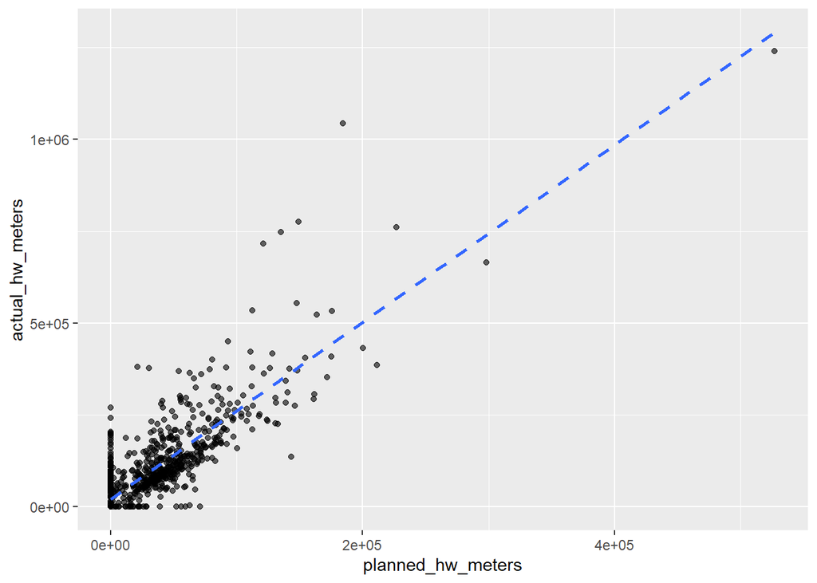

The graph above reveals that the relationship between the planned length of highway in a county (my instrument) and the actual length of highway in the county (my explanatory variable) appears to be approximately linear and positive. This is important because the monotonicity assumption requires that the intensity of treatment can only grow with the instrument. A positive linear relationship is a sign that the actual length of highway in the county tends to grow with the planned length of highway in a county, which seems to satisfy the assumption.

```r
fin_data_scatter <- fin_data %>%
  pivot_longer(
    cols = c(aqi_maximum, aqi_90th_percentile, aqi_median),
    names_to = "AQI_Measure",
    values_to = "AQI_Value"
)

ggplot(fin_data_scatter, aes(x = actual_hw_meters, y = AQI_Value, color = AQI_Measure)) +
  geom_point(alpha = 0.6) +
  geom_smooth(method = "lm", se = FALSE, linetype = "dashed") +
  labs(
    x = "Actual Highway Length (Meters)",
    y = "Air Quality Index (AQI)",
    color = "AQI Measure"
  ) +
  theme_minimal()
```

**Plot**

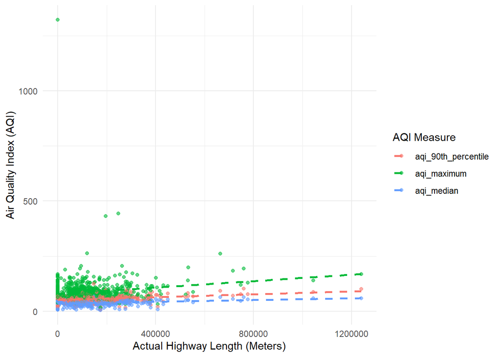

The graph above shows the relationship between the actual highway length and my dependent variables (AQI measures). There appears to be a positive linear relationship between the explanatory variable and each of the dependent variables. This is important because the OLS estimator used in generating the causal estimates requires that the underlying relationship is linear. Furthermore, the positive slope implies that there is a positive relationship between actual highway length and the AQI measures, which I expect to see reflected in my regression results. The difference in slope between the three lines implies that the relationship between the actual highway length and the maximum AQI is stronger than with the other two measures.

## Empirical Strategy

#### Identification Strategy and Causal Inference Method

My identification strategy is to use the length of highway planned for a county in the 1947 US Interstate Highway Plan to instrument for the length of highway in that county in 2019. The outcome variables ($Y_{ij}$) for this analysis are three separate measures of air quality in the counties in 2024: median AQI, 90th percentile AQI, and maximum AQI. The median AQI represents the “typical” air quality in a county. If the presence of highways influences the overall amount of air pollution in a county, I would expect to see a statistically significant relationship between the the length of highway in a county and median AQI. In contrast, the maximum AQI represents the most extreme air quality measured in a county. It may be the case that highways do not increase the typical air pollution of an area, but may instead cause or exacerbate extreme events that decrease air quality, such as wildfires. If that is the case, I would expect to see a statistically significant relationship between the the length of highway in a county and maximum AQI. In between these two measures in the 90th percentile AQI, which represents what a typical “bad” day, in terms of pollution, looks like without including extreme events that cause outlier measurements. The treatment variable ($D_{ij}$) is the length of highway present in a county in 2019. The instrument ($Z_{ij}$) is the length of highway planned for a county in the 1947 US Interstate Highway Plan. The control Variables ($X_{ij}$) include population, population density, the proportion of people living in urban areas, median age, median family income, and median years of schooling for individuals aged 25 and up from the year 1950. These variables are potentially confounding factors that may have influenced the amount of highways planned for an area and later the amount of air pollution in that area. In the following regression formulas, $\lambda_i$ represents a state fixed effect, i represents the state, and j represents the county.

First stage: $D_{ij} = \alpha_1 + \rho Z_{ij} + \omega_1 X_{ij} + \lambda_i + e_{ij}$

Second stage: $Y_{ij} = \alpha_2 + \delta \hat{D_{ij}} + \omega_2 X_{ij} + \lambda_i + e_{ij}$

#### Assumptions

The instrumental variable (IV) causal inference method relies on 3 main assumptions to produce credibly causal estimates of the treatment effects: relevancy, excludability, and monotonicity.

```r
#Calculates F-statistics
f1 <- fitstat(maximum_reg, type = "ivf")
w1 <- fitstat(maximum_reg, type = "ivwald")

#Creates dataframe of F-statistics
f_stats <- data.frame(
  "Standard F-Statistic" = c(f1$`ivf1::actual_hw_meters`$stat),
  "Wald F-Statistic" = c(w1$`ivwald1::actual_hw_meters`$stat)
)

kable(f_stats, align = 'c', digits = 1) %>%
  kable_classic()
```

| Standard.F.Statistic | Wald.F.Statistic |
| --- | --- |
| 1760.3 | 453.6 |

The excludability assumption is that the instrument only influences the outcome through the effect on the treatment. This assumption likely holds true because the 1947 US Interstate Highway Plan is unlikely to have any impacts on the modern day except through its influence on the amount and location of modern highways.

The monotonicity assumption dictates that, as the value of the instrument grows, the probability or intensity of the treatment can only grow with it. As I examined in the data section, the relationship between planned and actual highway length appears to be linear and positive. This demonstrates the tendency for the intensity of the treatment to grow with the value of the instrument.

#### Why Use an Instrumental Variable?

```r
maximum_reg2 <- feols(aqi_maximum ~ actual_hw_meters + population + proportion_urban_decimal + median_age_value + median_family_income_value + median_school_years_value + population_density | state, fin_data)

ninety_reg2 <- feols(aqi_90th_percentile ~ actual_hw_meters + population + proportion_urban_decimal + median_age_value + median_family_income_value + median_school_years_value + population_density | state, fin_data)

median_reg2 <- feols(aqi_median ~ actual_hw_meters + population + proportion_urban_decimal + median_age_value + median_family_income_value + median_school_years_value + population_density | state, fin_data)

models2 <- list(
  "Maximum AQI" = maximum_reg2,
  "90th Percentile AQI" = ninety_reg2,
  "Median AQI" = median_reg2
)

modelsummary(models2, coef_map = "actual_hw_meters", gof_map = NA, fmt = 6, stars = TRUE)
```

|  | Maximum AQI | 90th Percentile AQI | Median AQI |
| --- | --- | --- | --- |
| actual_hw_meters | 0.000045** | 0.000025** | 0.000014** |
|  | (0.000015) | (0.000008) | (0.000004) |

+ p < 0.1, * p < 0.05, ** p < 0.01, *** p < 0.001

#### Strengths and Weaknesses

The greatest strength of using an instrument is that it can remove the effects of unseen endogeneity and confounding variables to produce an unbiased estimate of the treatment effect. Furthermore, IV has relatively simple assumptions necessary for a causal interpretation of the results. However, IV has a major weakness in that it estimates the local average treatment effect (LATE), unlike other causal inference methods, which estimate the average treatment effect (ATE). The LATE is unideal because it represents the causal effect of highway length on air pollution for counties in which the 1947 US Interstate Highway Plan influenced the length of the highway. This means that, even if I find a credibly causal relationship between highway length and air pollution, my estimated effect cannot be reliably applied outside of this context and thus cannot be generalized.

## Results

```r
models <- list(
  "Maximum AQI" = maximum_reg,
  "90th Percentile AQI" = ninety_reg,
  "Median AQI" = median_reg
)

modelsummary(models, coef_map = "fit_actual_hw_meters", gof_map = NA, fmt = 6, stars = TRUE)
```

|  | Maximum AQI | 90th Percentile AQI | Median AQI |
| --- | --- | --- | --- |
| fit_actual_hw_meters | 0.000035* | 0.000025* | 0.000015** |
|  | (0.000014) | (0.000011) | (0.000005) |

+ p < 0.1, * p < 0.05, ** p < 0.01, *** p < 0.001

As I previously explained, this IV will only estimate the LATE, so the coefficient estimates above represent the causal effect of highway length on air pollution for counties in which the 1947 US Interstate Highway Plan influenced the length of the highway. The estimated effect of one additional meter of highway on the maximum AQI in a county is about 0.000035 and is statistically significant. The estimated effect of one additional meter of highway on the 90th percentile AQI in a county is about 0.000025 and is statistically significant. The estimated effect of one additional meter of highway on the median AQI in a county is about 0.000015 and is statistically significant. Given that the AQI is a composite measure of air pollution, its interpretation is not especially clear. The AQI is divided into levels that indicate how dangerous the air is to breath. The following summarizes the classifications: 0-50, safe; 51-100 safe for most, but the most vulnerable to air pollution may be affected; 101-150, sensitive individuals likely to be affected and others are unlikely to experience effects; 151-200, sensitive individuals may experience greater health effects and others may experience some effects; 201-300, risk to all people; 301+, emergency (AirNow, n.d.). To demonstrate how impactful the estimated effect on AQI is, let us take Baldwin county, Alabama as an example. Baldwin had about 173664 meters of highway in 2019 which, when multiplied by my causal estimate for the median AQI, results in about 2.6 points greater AQI. This effect is rather small for an ordinary day, but the maximum AQI would increase by about 6 points. Once again, this impact is unlikely to cause problems by itself, but may put sensitive individuals at greater risk when combined with other determinants of air quality. In the following table I present the results of the same analysis except the dependent, explanatory, and instrumental variables are in logarithms (inverse hyperbolic sin is used to approximate a logarithm for planned and actual highway lengths because they contain values of 0).

```r
maximum_reg3 <- feols(log(aqi_maximum) ~ population + proportion_urban_decimal + median_age_value + median_family_income_value + median_school_years_value + population_density | state | asinh(actual_hw_meters) ~ asinh(planned_hw_meters), fin_data)

ninety_reg3 <- feols(log(aqi_90th_percentile) ~ population + proportion_urban_decimal + median_age_value + median_family_income_value + median_school_years_value + population_density| state | asinh(actual_hw_meters) ~ asinh(planned_hw_meters), fin_data)

median_reg3 <- feols(log(aqi_median) ~ population + proportion_urban_decimal + median_age_value + median_family_income_value + median_school_years_value + population_density | state | asinh(actual_hw_meters) ~ asinh(planned_hw_meters), fin_data)

models3 <- list(
  "Maximum AQI" = maximum_reg3,
  "90th Percentile AQI" = ninety_reg3,
  "Median AQI" = median_reg3
)

modelsummary(models3, coef_map = "fit_asinh(actual_hw_meters)", gof_map = NA, fmt = 6, stars = TRUE)
```

|  | Maximum AQI | 90th Percentile AQI | Median AQI |
| --- | --- | --- | --- |
| fit_asinh(actual_hw_meters) | 0.002324 | 0.003631 | 0.004301 |
|  | (0.003115) | (0.003043) | (0.003456) |

+ p < 0.1, * p < 0.05, ** p < 0.01, *** p < 0.001

In examining these results, there is an interesting reversal to note: maximum AQI now has the smallest estimated effect and median AQI has the largest. These new measures are elasticities: the percentage change in the variable when the length of highway in the county increases by 1%. The reversal occurred because maximum AQI, despite having a larger absolute change in AQI due to highway length, has a greater scale. As such, the percentage change in maximum AQI is smaller despite a larger absolute change. Unfortunately, these estimates are no longer statistically significant.

## References

AirNow. (n.d.). Air Quality Index (AQI) Basics https://www.airnow.gov/aqi/aqi-basics/

Brinkman, J. & Lin, J. (2022, August). Freeway Revolts! The Quality of Life Effects of Highways. Shapefile for the 1947 U.S. Interstate Highway Plan [dataset]. Federal Reserve Bank of Philadelphia. https://doi.org/10.21799/frbp.wp.2022.24

Daniela Fecht, Paul Fischer, Léa Fortunato, Gerard Hoek, Kees de Hoogh, Marten Marra, Hanneke Kruize, Danielle Vienneau, Rob Beelen, Anna Hansell, Associations between air pollution and socioeconomic characteristics, ethnicity and age profile of neighbourhoods in England and the Netherlands, Environmental Pollution, Volume 198, 2015, Pages 201-210, ISSN 0269-7491, https://doi.org/10.1016/j.envpol.2014.12.014.

Environmental Protection Agency. (n.d.). Pre-Generated Data Files. annual_aqi_by_county_2024.zip [dataset]. https://aqs.epa.gov/aqsweb/airdata/download_files.html

National Bureau of Economic Research. (2023, October). Transportation Economics in the 21st Century - Highway Data. Shapefile for the 1947 U.S. Interstate Highway Plan [dataset]. https://www.nber.org/research/data/transportation-economics-21st-century-highway-data#:~:text=7.-,Shapefile%20for%20the%201947%20U.S.%20Interstate%20Highway%20Plan,-Shapefile%20for%20the

Steven Manson, Jonathan Schroeder, David Van Riper, Katherine Knowles, Tracy Kugler, Finn Roberts, and Steven Ruggles. IPUMS National Historical Geographic Information System: Version 19.0 [dataset]. Minneapolis, MN: IPUMS. 2024. http://doi.org/10.18128/D050.V19.0

Wang, C., & Chang, C. (2023). Forecasting air quality index considering socioeconomic indicators and meteorological factors: A data granularity perspective. Journal of Forecasting, 42(5), 1261–1274. https://doi-org.proxy.lib.odu.edu/10.1002/for.2962

Weingroff, R.F. (n.d.). Original Intent: Purpose of the Interstate System 1954-1956. Federal Highway Administration. https://highways.dot.gov/highway-history/interstate-system/original-intent-purpose-interstate-system-1954-1956